# PROJECT 2

Ayush Meshram

2024-10-21

##Do the loan grades provided to each customer correlate to their loan repayment behavior based on income and loan status?

```r
data <- read.csv("E:/Project Dataset/cleaned_accepted_2013_to_2018Q4.csv")
# Display the first few rows and structure of the data
head(data)
```

[output not shown]

[output cut: 160 more lines]

```r
str(data)
```

[output not shown]

[output cut: 86 more lines]

```r
library(dplyr)

# Preprocess the data
# Assuming 'loan_status' has values 'Fully Paid' and 'Charged Off'
data <- data %>%
  mutate(loan_status_num = ifelse(loan_status == "Fully Paid", 1,
                                  ifelse(loan_status == "Charged Off", 0, NA)))
```

## 3.1 Loan Repayment By Grade

### BAR PLOT

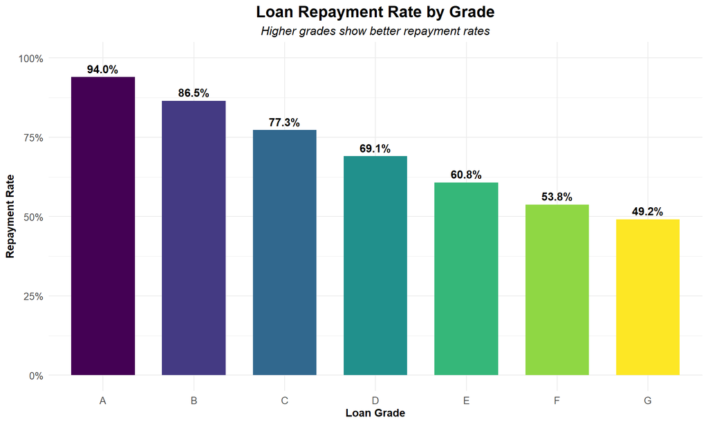

```r
# Create 'loan_status_binary' column
# Assuming "Fully Paid" = 1 and "Charged Off" = 0
data <- data %>%
  mutate(loan_status_binary = ifelse(loan_status == "Fully Paid", 1,
                                     ifelse(loan_status == "Charged Off", 0, NA)))

# Calculate repayment rate by grade
repayment_rate <- data %>%
  group_by(grade) %>%
  summarise(repayment_rate = mean(loan_status_binary, na.rm = TRUE)) %>%
  mutate(grade = factor(grade, levels = c("A", "B", "C", "D", "E", "F", "G")))  # Ensure correct order

# Create the enhanced bar plot
ggplot(repayment_rate, aes(x = grade, y = repayment_rate, fill = grade)) +
  geom_bar(stat = "identity", width = 0.7) +
  geom_text(aes(label = scales::percent(repayment_rate, accuracy = 0.1)),
            vjust = -0.5, size = 4, fontface = "bold") +
  scale_y_continuous(labels = scales::percent_format(), limits = c(0, 1)) +
  scale_fill_viridis_d() +
  labs(title = "Loan Repayment Rate by Grade",
       subtitle = "Higher grades show better repayment rates",
       x = "Loan Grade",
       y = "Repayment Rate") +
  theme_minimal() +
  theme(
    plot.title = element_text(hjust = 0.5, size = 16, face = "bold"),
    plot.subtitle = element_text(hjust = 0.5, size = 12, face = "italic"),
    axis.title = element_text(face = "bold"),
    axis.text = element_text(size = 10),
    legend.position = "none"
  )
```

-Clear correlation between grade and repayment: There’s a strong positive relationship between loan grade and repayment rate. As the grade improves from G to A, the repayment rate steadily increases.

-Significant gap between top and bottom grades: The highest grade (A) has a repayment rate of 94%, while the lowest grade (G) is at 49.2% - a difference of nearly 45 percentage points. This highlights the substantial risk difference between the best and worst-rated loans.

## 3.2 Income Distribution By Loan Grade

### BOX PLOT

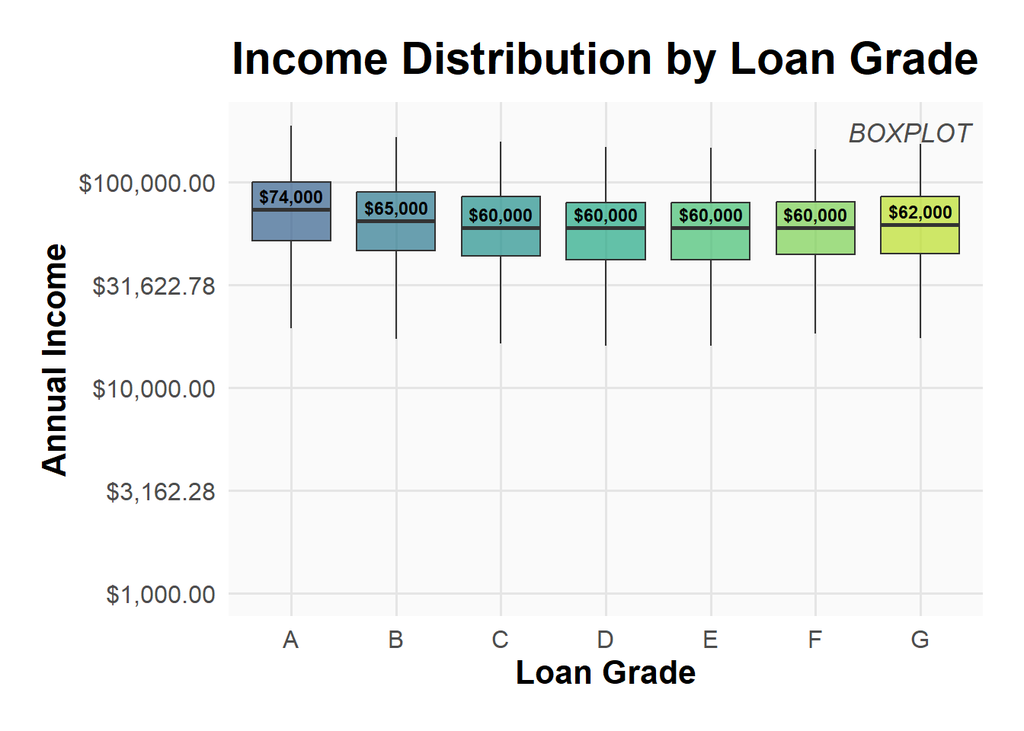

```r
# Function to remove outliers using IQR method
remove_outliers <- function(x) {
  qnt <- quantile(x, probs = c(0.25, 0.75), na.rm = TRUE)
  H <- 1.5 * IQR(x, na.rm = TRUE)
  x[x < (qnt[1] - H) | x > (qnt[2] + H)] <- NA
  return(x)
}

# Prepare the data and remove outliers
plot_data <- data %>%
  filter(!is.na(annual_inc) & annual_inc > 0) %>%
  mutate(grade = factor(grade, levels = c("A", "B", "C", "D", "E", "F", "G"))) %>%
  group_by(grade) %>%
  mutate(annual_inc_clean = remove_outliers(annual_inc)) %>%
  filter(!is.na(annual_inc_clean)) %>%
  ungroup()

# Calculate median income for annotation
median_incomes <- plot_data %>%
  group_by(grade) %>%
  summarise(median_income = median(annual_inc_clean))

# Create the enhanced boxplot without outliers
income_plot <- ggplot(plot_data, aes(x = grade, y = annual_inc_clean, fill = grade)) +
  geom_boxplot(alpha = 0.7, outlier.shape = NA) +
  geom_text(data = median_incomes, aes(y = median_income, label = scales::dollar(median_income)),
            vjust = -0.5, size = 3, fontface = "bold") +
  scale_y_log10(labels = scales::dollar_format(),
                breaks = scales::trans_breaks("log10", function(x) 10^x),
                minor_breaks = NULL,
                limits = c(1000, NA)) +  # Set lower limit to reduce space
  scale_fill_viridis_d(option = "D", begin = 0.3, end = 0.9) +
  labs(title = "Income Distribution by Loan Grade",
       x = "Loan Grade",
       y = "Annual Income") +
  theme_minimal(base_size = 14) +
  theme(
    plot.title = element_text(hjust = 0.5, size = 22, face = "bold", margin = margin(b = 10)),
    axis.title = element_text(face = "bold", size = 16),
    axis.text = element_text(size = 12),
    legend.position = "none",
    panel.grid.major = element_line(color = "gray90"),
    panel.grid.minor = element_blank(),
    plot.background = element_rect(fill = "white", color = NA),
    panel.background = element_rect(fill = "gray98", color = NA),
    plot.margin = margin(t = 20, r = 20, b = 20, l = 20)
  ) +
  coord_cartesian(clip = "off") +
  annotate("text", x = Inf, y = Inf, label = "BOXPLOT",
           hjust = 1.1, vjust = 2, size = 4.5, fontface = "italic", color = "gray30")

# Display the plot (optional)
print(income_plot)
```

```r
# Save the plot
ggsave("income_distribution_boxplot_no_outliers.png", plot = income_plot, width = 12, height = 8, dpi = 300)
```

–Higher income for better grades: There’s a clear trend of higher median incomes for better loan grades. Grade A has the highest median income at $74,000, while lower grades (C through G) have lower median incomes around $60,000-$62,000.

–Income disparity narrows in lower grades: The income distributions for grades C through G are very similar, with median incomes clustered closely together. This suggests that factors other than income may be more influential in determining these lower grades.

## Data Preparation for Heatmap Analysis

```r
# Create income brackets
# Create income brackets
data <- data %>%
  mutate(income_bracket = cut(annual_inc,
                              breaks = quantile(annual_inc, probs = seq(0, 1, 0.2), na.rm = TRUE),
                              labels = c('Very Low', 'Low', 'Medium', 'High', 'Very High'),
                              include.lowest = TRUE))

# Reorder income_bracket factor levels
data$income_bracket <- factor(data$income_bracket,
                              levels = c('Very High', 'High', 'Medium', 'Low', 'Very Low'))

# Calculate repayment rates
repayment_rates <- data %>%
  group_by(grade, income_bracket) %>%
  summarize(repayment_rate = mean(loan_status_binary, na.rm = TRUE)) %>%
  pivot_wider(names_from = income_bracket, values_from = repayment_rate)

# Display the repayment rates
print(repayment_rates)
```

```
## # A tibble: 7 × 6
## # Groups:   grade [7]
##   grade `Very High`  High Medium   Low `Very Low`
##   <chr>       <dbl> <dbl>  <dbl> <dbl>      <dbl>
## 1 A           0.950 0.945  0.939 0.936      0.914
## 2 B           0.881 0.873  0.866 0.861      0.846
## 3 C           0.800 0.784  0.769 0.765      0.755
## 4 D           0.732 0.701  0.686 0.676      0.676
## 5 E           0.662 0.622  0.590 0.584      0.599
## 6 F           0.602 0.544  0.526 0.516      0.522
## 7 G           0.571 0.499  0.482 0.460      0.461
```

## 3.3 Repayment Rate by Grade and Income Bracket

### HEATMAP

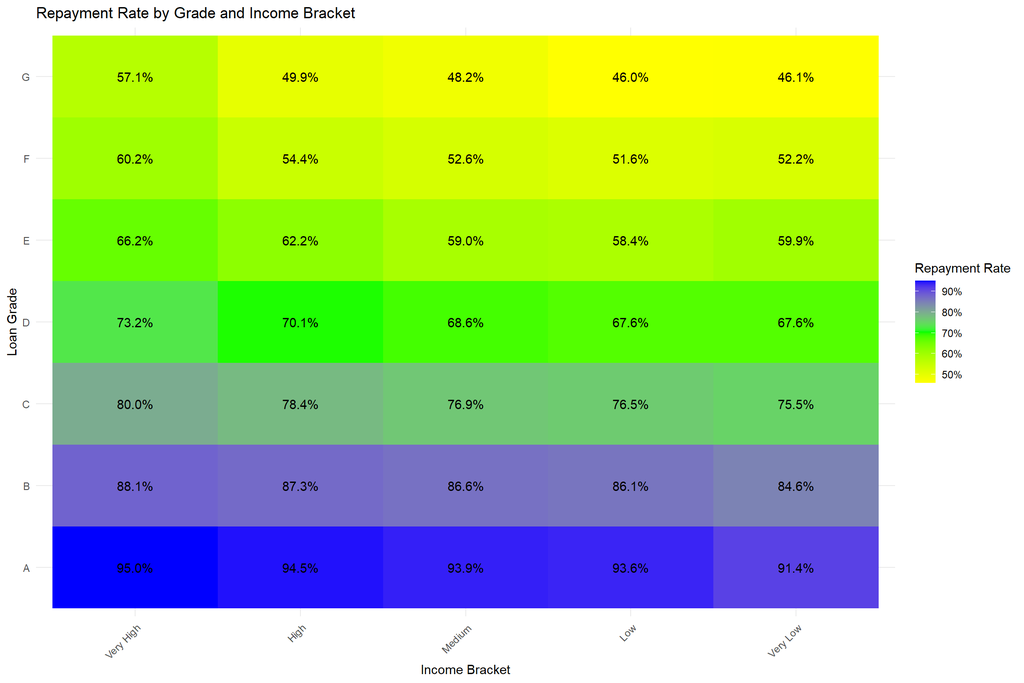

```r
# Prepare data for heatmap
heatmap_data <- repayment_rates %>%
  pivot_longer(cols = -grade, names_to = "income_bracket", values_to = "repayment_rate")

# Ensure income_bracket is a factor with correct order
heatmap_data$income_bracket <- factor(heatmap_data$income_bracket,
                                      levels = c('Very High', 'High', 'Medium', 'Low', 'Very Low'))

# Create heatmap
ggplot(heatmap_data, aes(x = income_bracket, y = grade, fill = repayment_rate)) +
  geom_tile() +
  geom_text(aes(label = scales::percent(repayment_rate, accuracy = 0.1)), color = "black") +
  scale_fill_gradientn(colors = c("yellow", "green", "blue"),
                       labels = scales::percent_format(accuracy = 1),
                       name = "Repayment Rate") +
  labs(title = "Repayment Rate by Grade and Income Bracket",
       x = "Income Bracket",
       y = "Loan Grade") +
  theme_minimal() +
  theme(axis.text.x = element_text(angle = 45, hjust = 1))
```

–Grade is the primary determinant of repayment: There’s a clear vertical gradient showing that loan grade has a stronger influence on repayment rates than income. Grade A loans consistently have the highest repayment rates (91-95%) across all income brackets, while Grade G loans have the lowest (46-57%)

–Income impact varies by grade: For higher-grade loans (A-C), income has minimal effect on repayment rates. However, for lower-grade loans (D-G), there’s a more noticeable positive correlation between income and repayment rates, particularly for the “Very High” income bracket.

–Surprising trend in lowest grades: Counterintuitively, for the lowest grades (F-G), the “Very High” income bracket shows higher repayment rates than some middle income brackets. This suggests that high-income borrowers with poor credit scores might be better risks than their grades suggest.

## 3.4 ANOVA Test

```r
# Perform ANOVA to test for income differences across grades
anova_result <- aov(annual_inc ~ grade, data = data)

# Display the ANOVA summary
anova_summary <- summary(anova_result)

# Print the ANOVA results
cat("ANOVA test results for income differences across grades:\n")
```

```
## ANOVA test results for income differences across grades:
```

```r
cat(sprintf("F-statistic = %.2f, p-value = %.4f\n",
            anova_summary[[1]]$`F value`[1],
            anova_summary[[1]]$`Pr(>F)`[1]))
```

```
## F-statistic = 1260.67, p-value = 0.0000
```

–ANOVA test results for income differences across grades: F-statistic = 1260.67, p-value = 0.0000

–Statistically significant difference: The extremely low p-value (0.0000) indicates there are highly statistically significant differences in income levels across loan grades. This suggests that income is a meaningful factor in determining loan grades.

–Confirmation of visual trends: These results statistically confirm the visual trends observed in previous charts, where higher loan grades were associated with higher incomes. The ANOVA provides robust evidence that these income differences across grades are not due to chance.

## 3.5 Chi Square Test Grade Vs Loan Status

```r
# Create a contingency table
contingency_table <- table(data$grade, data$loan_status)

# Perform chi-square test
chi_square_result <- chisq.test(contingency_table)

# Extract results
chi2 <- chi_square_result$statistic
p_value <- chi_square_result$p.value
dof <- chi_square_result$parameter

# Print results
cat(sprintf("Chi-square test results: chi2 = %.2f, p-value = %.4f\n",
            chi2, p_value))
```

```
## Chi-square test results: chi2 = 123374.94, p-value = 0.0000
```

```r
cat(sprintf("Degrees of freedom: %d\n", dof))
```

```
## Degrees of freedom: 36
```

```r
# Print contingency table
cat("\nContingency table:\n")
```

```
##
## Contingency table:
```

```r
print(contingency_table)
```

```
##
##     Charged Off Current Default Fully Paid In Grace Period Late (16-30 days)
##   A       12767  195539       5     200432             632               341
##   B       48471  262903       7     311162            1771               993
##   C       81750  255707       8     277973            2993              1476
##   D       57983  115138      13     129402            1899               969
##   E       34228   38080       6      53028             799               402
##   F       13654    8485       1      15896             240               129
##   G        4342    2465       0       4197             102                39
##
##     Late (31-120 days)
##   A               1322
##   B               4788
##   C               7554
##   D               4761
##   E               2166
##   F                640
##   G                236
```

```r
# Print expected frequencies
cat("\nExpected frequencies:\n")
```

```
##
## Expected frequencies:
```

```r
print(chi_square_result$expected)
```

```
##
##     Charged Off Current Default Fully Paid In Grace Period Late (16-30 days)
##   A       48229  167303   7.619     188974          1606.9             828.4
##   B       73932  256464  11.680     289686          2463.3            1269.9
##   C       73623  255392  11.631     288475          2453.0            1264.6
##   D       36393  126245   5.749     142598          1212.5             625.1
##   E       15102   52388   2.386      59174           503.2             259.4
##   F        4581   15892   0.724      17951           152.6              78.7
##   G        1335    4632   0.211       5232            44.5              22.9
##
##     Late (31-120 days)
##   A               4089
##   B               6268
##   C               6242
##   D               3086
##   E               1280
##   F                388
##   G                113
```

–Grade A outperforms expectations: Comparing observed to expected frequencies, Grade A loans have far more “Fully Paid” outcomes (200,432 vs 188,974 expected) and fewer “Charged Off” outcomes (12,767 vs 48,229 expected) than expected. This underscores the lower risk associated with top-grade loans.

–Lower grades struggle more: Grades E, F, and G show higher frequencies of “Charged Off” and “Late” payments compared to their expected values. This aligns with the higher risk profile of lower-grade loans and supports the trends seen in previous analyses.

## Interpretation Of chi Square Test

```r
# Interpretation
cat("\nInterpretation:\n")
```

```
##
## Interpretation:
```

```r
if (p_value < 0.05) {
  cat("The chi-square test shows a statistically significant association between Grade and Loan Status (p < 0.05).")
  cat("\nThis suggests that the loan grade is not independent of the loan status.")
} else {
  cat("The chi-square test does not show a statistically significant association between Grade and Loan Status (p >= 0.05).")
  cat("\nThis suggests that the loan grade might be independent of the loan status.")
}
```

```
## The chi-square test shows a statistically significant association between Grade and Loan Status (p < 0.05).
## This suggests that the loan grade is not independent of the loan status.
```

```r
# Effect size (Cramer's V)
n <- sum(contingency_table)
min_dim <- min(dim(contingency_table)) - 1
cramer_v <- sqrt(chi2 / (n * min_dim))

cat(sprintf("\n\nEffect size (Cramer's V): %.4f\n", cramer_v))
```

```
##
##
## Effect size (Cramer's V): 0.0976
```

```r
cat("Interpretation of Cramer's V:\n")
```

```
## Interpretation of Cramer's V:
```

```r
if (cramer_v < 0.1) {
  cat("Negligible association")
} else if (cramer_v < 0.3) {
  cat("Weak association")
} else if (cramer_v < 0.5) {
  cat("Moderate association")
} else {
  cat("Strong association")
}
```

```
## Negligible association
```

–Interpretation: The chi-square test shows a statistically significant association between Grade and Loan Status (p < 0.05). This suggests that the loan grade is not independent of the loan status.

Effect size (Cramer’s V): 0.0976 Interpretation of Cramer’s V: Negligible association

## 3.6 Loan Status Distribution By Grade

### STACKED BAR CHART

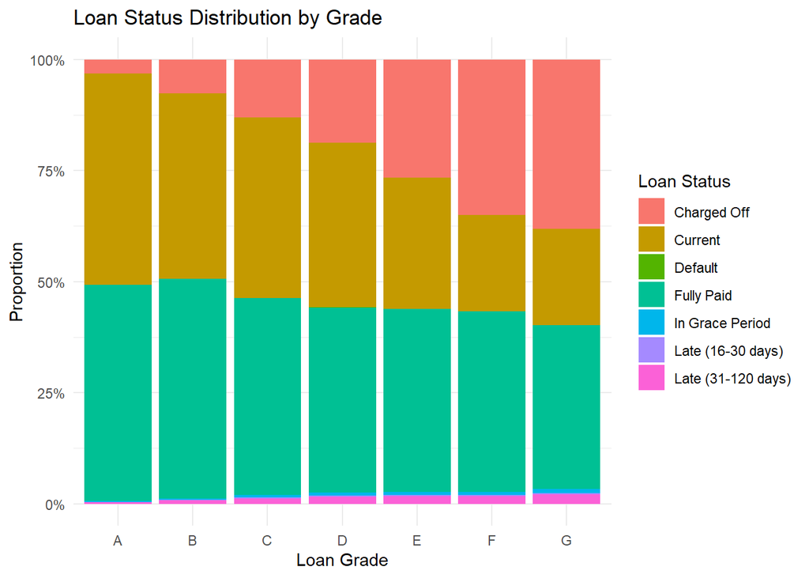

```r
#3. Loan Status Distribution by Grade
data %>%
  ggplot(aes(x = grade, fill = loan_status)) +
  geom_bar(position = "fill") +
  labs(title = "Loan Status Distribution by Grade",
       x = "Loan Grade", y = "Proportion",
       fill = "Loan Status") +
  theme_minimal() +
  scale_y_continuous(labels = scales::percent_format())
```

–Inverse relationship between grade and charge-offs: There’s a clear trend of increasing charge-off rates as the loan grade decreases. Grade A loans have the lowest proportion of charge-offs, while Grade G has the highest. This reinforces the higher risk associated with lower-grade loans.

–Fully paid loans dominate higher grades: Grades A and B show a significantly higher proportion of fully paid loans compared to lower grades. This indicates that higher-grade loans are more likely to be repaid in full, aligning with their lower risk profile.